# IBP’s meta-analysis

Thuila Maia, Izonete Cristina Guiloski e [Henrique Laureano](https://henriquelaureano.github.io/)

Last modification on* 2022-02-11 10:27:12

> The measures and metrics computed in a meta-analysis are:
> - *Q*: Cochran’s test statistic for the residual heterogeneity, approximated from the chi-square distribution;
> - $I^{2}$: estimated (in percent) amount of unaccounted variability (which is composed of residual heterogeneity plus sampling variability) that can be attributed to residual heterogeneity;
> - $\tau^{2}$: estimated amount of residual heterogeneity;
> - $Q_{M}$: if the variables/moderators are statistically significant, together. i.e., if there is a difference between levels in a general sense.

> The results are presented in a *forest plot*. Individual study estimates are represented as black boxes on the continuous horizontal line, which represents the 95% confidence interval (CI).

> The meta-analysis was performed with the `R` language and environment for statistical computing (R Core Team, 2021), via the `{metafor}` (Viechtbauer, 2010) package.

> R Core Team (2021). R: A language and environment for statistical computing. R Foundation for Statistical Computing, Vienna, Austria. URL https://www.R-project.org/

> Viechtbauer, W. (2010). Conducting meta-analyses in R with the metafor package. Journal of Statistical Software, 36(3), 1-48. https://doi.org/10.18637/jss.v036.i03

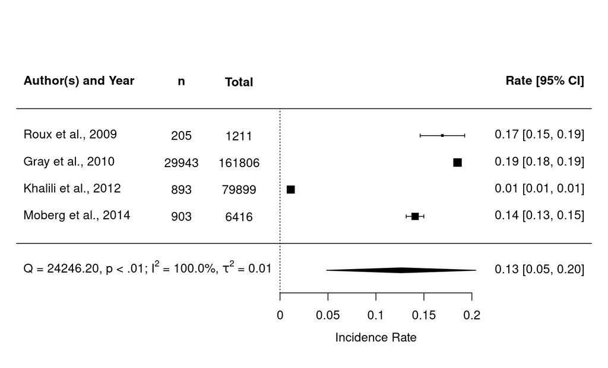

> **Number of fractures**: Cochran’s Q (Q=24246.20, df=3, p<0.01), approximated from the chi-square distribution, is significant, and the I2 value of 100%, confirming the heterogeneity of the meta-analysis across the subjective studies. The pooled estimate for the prevalence for the overall cohort was 13% with a 95% CI of 5-20%.

> Here, we compared the number of fractures with the total number of participants, not the number of patients using IBP.

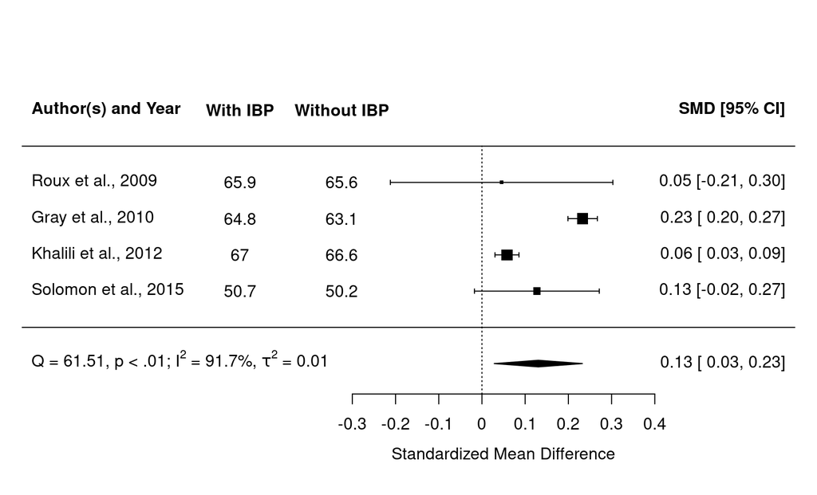